# A hypothesis test of feasibility for pilot trials assessing recruitment, follow-up and adherence rates

### Alternative perspective

Rather than keeping the hypotheses fixed and looking for the error rates which can be obtained, we could instead constrain the type II error at some desired value and then look at how much type I error we will get for different hypotheses. Specifically, we can find the $c$ which will give a desired type II in the pilot for a fixed alternative defined by $p_1$, and then find the type I which results from a range of $p_0$.

```r
n <- 70; n_e <- 1000; n_t <- 514

exp_ns <- NULL
for(s in 0:1000){
  r_est <- 2*n/(s+2*n)
  x <- 0
  for(k in 0:(n_t-1)){
    x <- x + dbinom(k, n_e, r_est)*k
  }
  exp_ns <- c(exp_ns, x + n_t*(1 - pbinom(n_t-1, n_e, r_est)))
}
# Under perfect adherence and follow-up, will need an expected sample size of at least
# 4c^2 / mu^2
# to get a positive result
exp_ns <- exp_ns[exp_ns >= (4*2.46^2)/(mu^2)]

# Manually find a c that gives approx 90% pilot power,
# for n_p = 30, 50, 70
psoptim(rep(NA,2), fn=get_oc2_opt,
        upper = c(1,1), lower = c(0.1,0.1),
                 c=2.57, n=70, x=x1, a=F, mu=0.3, n_e=1000, n_t=514, exp_ns=exp_ns,
        control=list(trace=1, reltol = 0.01, maxit = 200))
cs <- c(2.46, 2.53, 2.57)

MO_alt <- function(pars, c, n, a, mu, n_e, n_t, exp_ns)
{
  x0 <- qnorm(pars[1]) + qnorm(0.975)
  c(pars[1], get_oc2_opt(pars[2:4], c=c, n=n_p, x=x0, a=a, mu=0.3, n_e=1000, n_t=514, exp_ns=exp_ns))
}

# For a range of p_0 and n_p, find the type I error
df <- NULL
for(n_p in c(30, 50, 70)){
      print(n_p)

    c <- cs[which(c(30, 50, 70) == n_p)]

    exp_ns <- NULL
    for(s in 0:1000){
      r_est <- 2*n_p/(s+2*n_p)
      x <- 0
      for(k in 0:(n_t-1)){
        x <- x + dbinom(k, n_e, r_est)*k
      }
      exp_ns <- c(exp_ns, x + n_t*(1 - pbinom(n_t-1, n_e, r_est)))
    }
    exp_ns <- exp_ns[exp_ns >= (4*c^2)/(mu^2)]

    opt <- nsga2(MO_alt, 3,2,lower.bounds = c(0.45,0.1,0.1), upper.bounds = c(0.8, 1,1),
                 generations = 500, popsize = 200,
             c=c, n=n_p, a=T, mu=0.3, n_e=1000, n_t=514, exp_ns=exp_ns)

    df <- rbind(df, data.frame(p0 = opt$value[,1], a =-opt$value[,2], n_p=n_p))
}

plot(df[,1:2])

saveRDS(df, "./data/alt_data.Rda")
```

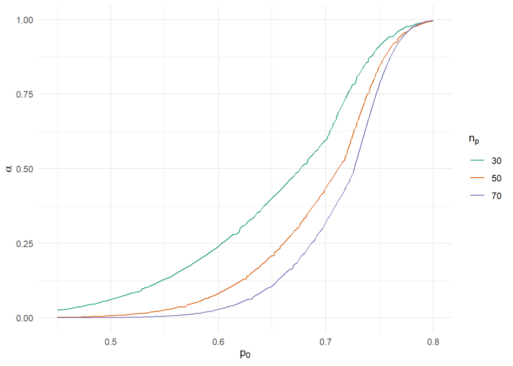

```r
df <- readRDS("./data/alt_data.Rda")

ggplot(df, aes(p0, a, colour=as.factor(n_p))) + geom_line() + #geom_smooth(span=0.4) +
  scale_color_manual(name=expression(n[p]), values=cols) +
  xlab(expression(p[0])) + ylab(expression(alpha)) +
  theme_minimal()
```

```r
#ggsave("./paper/figures/alt.pdf", height=9, width=14, units="cm")
#ggsave("./paper/figures/alt.eps", height=9, width=14, units="cm", device = cairo_ps())
```

### Comparator

We can comapre the error rate curve of the proposed method against that of the current approach, where the three parameter estimates are compared against seperate progression criteria thresholds and a “go” decision is made only if they are all exceeded. The optimisation strategy is based on a simple grid search at the inner (over the hypotheses) level.

```r
get_pf <- function(phi, xi, mu, n_e, n_t)
{
  p_r <- phi[1]; p_a <- phi[2]; sd <- 1
  if(any(c(p_r,p_a) < 0) | any(c(p_r,p_a) > 1) ){return(1000)}
  exp_n <- get_exp_N(n_e, n_t, p_r)
  (4*sd^2 + 2*mu^2 *p_a*(1-p_a))*xi^2/((p_a*mu)^2*exp_n)
}

get_oc_pc <- function(cs, n, m, tI)
{
  # Recruitment
  s <- floor(2*n/cs[1] - 2*n)
  # Adherence
  a <- cs[2]*n
  # Follow-up
  f <- cs[3]*2*n

  (tI*-1 + !tI*1)*pnbinom(s, 2*n, m[,1])*(1- pbinom(f, 2*n, m[,3]))*(1 - pbinom(a, n, m[,2]))
}

# for example,

m0 <- expand.grid(p_r = seq(0,1,0.005), p_a= seq(0,1,0.005))
m0$p_f <- apply(m0, 1, get_pf, xi=x0, mu=0.3, n_e=1000, n_t=514)
m0 <- m0[m0$p_f <= 1,]

m1 <- expand.grid(p_r = seq(0,1,0.005), p_a= seq(0,1,0.005))
m1$p_f <- apply(m1, 1, get_pf, xi=x1, mu=0.3, n_e=1000, n_t=514)
m1 <- m1[m1$p_f <= 1,]

cs <- c(0.3, 0.8, 0.7)

alphas <- get_oc_pc(cs, n=50, m=m0, tI=T)
betas <- get_oc_pc(cs, n=50, m=m1, tI=F)

c(-min(alphas), 1-min(betas))
```

```
## [1] 0.9783583 0.7104136
```

We can search over all possible progression criteria and plot the best available error rates using nsga-II:

```r
MO_pc <- function(cs, n, m0, m1)
{
  alphas <- -get_oc_pc(cs, n=n, m=m0, tI=T)
  pows <- get_oc_pc(cs, n=n, m=m1, tI=F)

  c(max(alphas), 1-min(pows))
}

opt <- nsga2(MO_pc, 3, 2,
             lower.bounds = rep(0,3), upper.bounds = rep(1,3),
             n=30, m0=m0, m1=m1)

df <- data.frame(a=opt$value[,1], b=opt$value[,2])

ggplot(df, aes(a,b)) + geom_point() + geom_step() +
  theme_minimal() + coord_fixed()
```